# writeup

Yuting Mei

September 26, 2021

# 1 Introduction

In this blog, we are going to use two different ways to solve the following question: In a class of N individuals, what is the probability that at least two students will share a birthday?

## 1.1 Assumption

- birthdays are equally likely to fall on any day of the year, ignoring leap year.
- Every day of the year can be picked when sampling.
- The birthdays among students are evenly distributed throughout the year, and there are no special circumstances such as twins.
- Assuming that there are 365 days in a year, leap years are not considered.

# 2 Method

## 2.1 Simulation

### 2.1.1 Definition

Simulation is a way to model random events, such that simulated outcomes closely match real-world outcomes. By observing simulated outcomes, researchers gain insight on the real world.

### 2.1.2 Why Simulation

Some situations do not lend themselves to precise mathematical treatment. Others may be difficult, time-consuming, or expensive to analyze. In these situations, simulation may approximate real-world results; yet, require less time, effort, and/or money than other approaches.

### 2.1.3 How to Conduct a Simulation

A simulation is useful only if it closely mirrors real-world outcomes. The steps required to produce a useful simulation are presented below.

- Describe the possible outcomes.
- Link each outcome to one or more random numbers.
- Choose a source of random numbers.
- Choose a random number.
- Based on the random number, note the “simulated” outcome.
- Repeat steps 4 and 5 multiple times; preferably, until the outcomes show a stable pattern.
- Analyze the simulated outcomes and report results.

For more information about the related terminology, methology and examples about statistical simulation method, you can click the following link to have a look: 02-monte-carlo-error:https://github.com/vanderbilt-data-science/probability-and-inference-portfolio-mei-yuting/tree/main/02-monte-carlo-error

## 2.2 Analytic

We can first discuss the complement of this problem, that is, the probability of two different birthdays among all students in a certain class size. Assuming that the size of the class size is n, then when n<365, the probability that the birthday from the first person to the nth person is different is 1,364/365, 363/365. . . , (365-n+1)/365. Therefore, when the class size is n, the probability that at least two students in the class have the same birthday is $P(n) = 1- \frac{365!}{365^n(365-n)!}$

# 3 Result

```r
library(ggplot2)
library(dplyr)
```

```r
# analytic solution
prob_sum = c()
prob_a = c()
for (i in 1:80){
  prob_a[i] =  1 - (factorial(i) * choose(365, i) / 365 ^ i)
}

# simulation solution
replicates = c()
generate_class <- function(class_size){
  birthdays <- sample(1:365, class_size, replace = TRUE)
  data.frame(student_id = 1:class_size, birthday = birthdays)
}

check_birthday <- function(class){
  class_summary <- class %>%
    summarize(n = n(), n_bday = n_distinct(birthday)) %>%
    mutate(shared = n > n_bday)
  class_summary[["shared"]]
}

for(i in 1:80){
  replicates[i] <- replicate(1000, i %>% generate_class %>% check_birthday) %>% mean()
}

prob_sum$analytic = c(prob_a)
prob_sum$simulation = c(replicates)
prob_sum = data.frame(prob_sum)
```

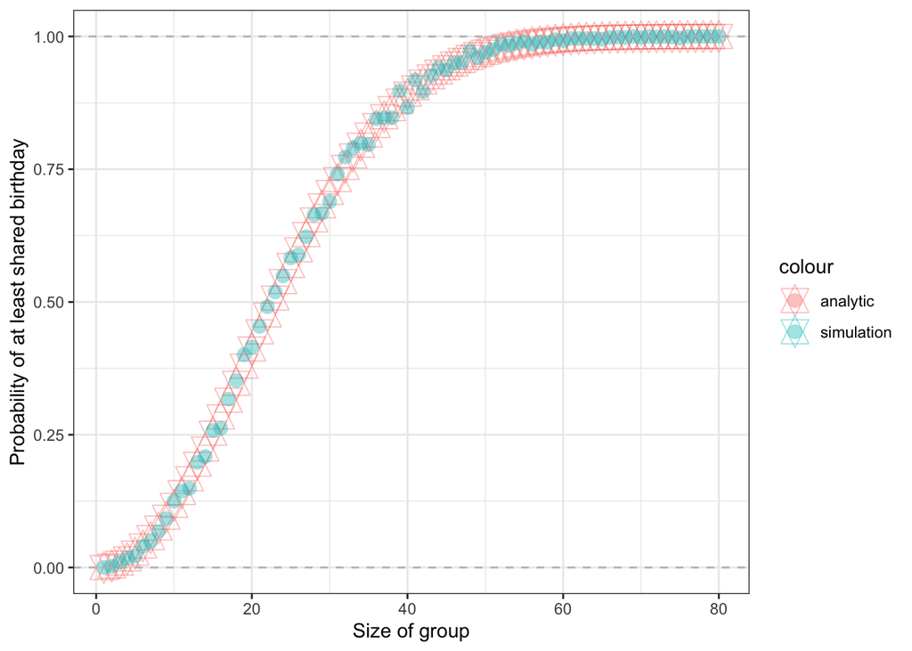

```r
prob_sum %>%
  ggplot(aes(x = seq(1, 80))) +
  geom_point(aes(y = analytic, color = 'analytic'),  alpha = 0.4, size = 5, pch = 11) +
  geom_point(aes(y = simulation, color = 'simulation'),  alpha = 0.4, size = 3.5, pch = 16) +
  labs(x = "Size of group", y = "Probability of at least shared birthday") +
  geom_hline(aes(yintercept = 1), color = "grey", linetype = "dashed") +
  geom_hline(aes(yintercept = 0), color = "grey", linetype = "dashed") +
  theme_bw()
```

The figure above shows the solution to this problem using two different tools. The x-axis represents the class size from 1 to 80, and the y-axis represents the corresponding probability values obtained using the two methods of analytic and simulation.

# 4 Conclusion

- When the class size gradually increases, the probability that two or more students have the same probability also increases.
- When the class size exceeds 50, the probability that two or more students have the same birthday is almost close to 1.

# 5 Comparison

## 5.1 Prons and Cons with Simulation Method

- It can solve the problem of statistical properties when the sample distribution is unknown, and calculate the corresponding probability.
- The problem of determinism should be transformed into a problem of randomness to be solved.
- The simulation results have random errors.
- Usually a lot of samples are needed for simulation, which is very time-consuming.

## 5.2 Prons and Cons with Analytic Method

- There is no random error in the result, because the distribution of the sample and the population is exactly the same.
- The calculation speed is much faster than the simulation method.
- It is necessary to know the probability distribution that the sample obeys, and in real-world research, we cannot know the probability distribution function of the sample in most cases.